# lab1

anjal hussan

9/4/2017

## R Markdown

```r
source("http://www.openintro.org/stat/data/cdc.R")
```

```r
names(cdc)
```

```
## [1] "genhlth"  "exerany"  "hlthplan" "smoke100" "height"   "weight"
## [7] "wtdesire" "age"      "gender"
```

# Exercise 1:

## How many cases are there in this data set? How many variables? For each variable, identify its data type (e.g. categorical, discrete).

## Ans:

## Total number of Cases:

```r
nrow(cdc)
```

```
## [1] 20000
```

## Number of variables

```r
ncol(cdc)
```

```
## [1] 9
```

## Data type:

```r
str(cdc)
```

```
## 'data.frame':    20000 obs. of  9 variables:
##  $ genhlth : Factor w/ 5 levels "excellent","very good",..: 3 3 3 3 2 2 2 2 3 3 ...
##  $ exerany : num  0 0 1 1 0 1 1 0 0 1 ...
##  $ hlthplan: num  1 1 1 1 1 1 1 1 1 1 ...
##  $ smoke100: num  0 1 1 0 0 0 0 0 1 0 ...
##  $ height  : num  70 64 60 66 61 64 71 67 65 70 ...
##  $ weight  : int  175 125 105 132 150 114 194 170 150 180 ...
##  $ wtdesire: int  175 115 105 124 130 114 185 160 130 170 ...
##  $ age     : int  77 33 49 42 55 55 31 45 27 44 ...
##  $ gender  : Factor w/ 2 levels "m","f": 1 2 2 2 2 2 1 1 2 1 ...
```

# Data Type:

genhlth : Categorical exerany : Discrete hlthplan: Discrete smoke100: Discrete height : Numerical + categorical weight : Numerical+categorical wtdesire: Numerical+ categorical age : Numerical+ categorical gender : Categorical

```r
head(cdc)
```

```
##     genhlth exerany hlthplan smoke100 height weight wtdesire age gender
## 1      good       0        1        0     70    175      175  77      m
## 2      good       0        1        1     64    125      115  33      f
## 3      good       1        1        1     60    105      105  49      f
## 4      good       1        1        0     66    132      124  42      f
## 5 very good       0        1        0     61    150      130  55      f
## 6 very good       1        1        0     64    114      114  55      f
```

```r
tail(cdc)
```

```
##         genhlth exerany hlthplan smoke100 height weight wtdesire age
## 19995      good       0        1        1     69    224      224  73
## 19996      good       1        1        0     66    215      140  23
## 19997 excellent       0        1        0     73    200      185  35
## 19998      poor       0        1        0     65    216      150  57
## 19999      good       1        1        0     67    165      165  81
## 20000      good       1        1        1     69    170      165  83
##       gender
## 19995      m
## 19996      f
## 19997      m
## 19998      f
## 19999      f
## 20000      m
```

```r
summary(cdc$weight)
```

```
##    Min. 1st Qu.  Median    Mean 3rd Qu.    Max.
##    68.0   140.0   165.0   169.7   190.0   500.0
```

```r
190 - 140
```

```
## [1] 50
```

```r
mean(cdc$weight)
```

```
## [1] 169.683
```

```r
var(cdc$weight)
```

```
## [1] 1606.484
```

```r
median(cdc$weight)
```

```
## [1] 165
```

### Total number of times each kind of response

```r
table(cdc$smoke100)
```

```
##
##     0     1
## 10559  9441
```

### Relative frequency distribution

```r
table(cdc$smoke100)/20000
```

```
##
##       0       1
## 0.52795 0.47205
```

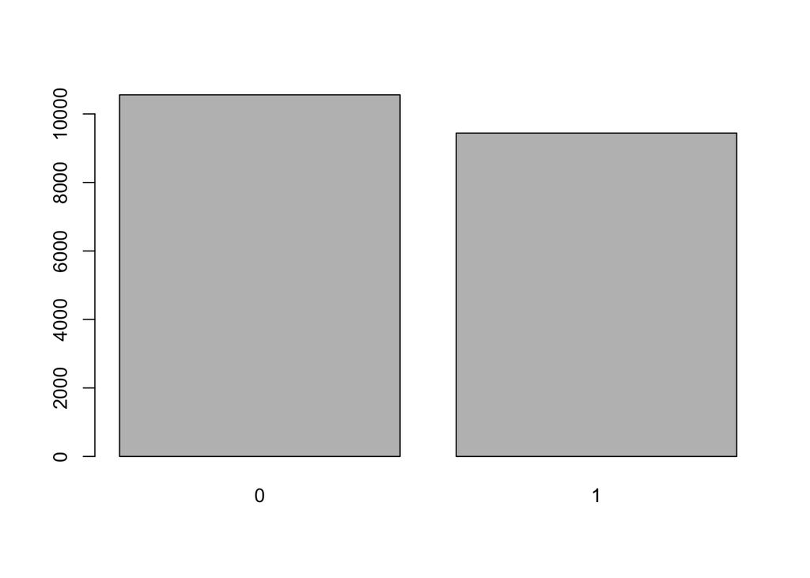

```r
barplot(table(cdc$smoke100))
```

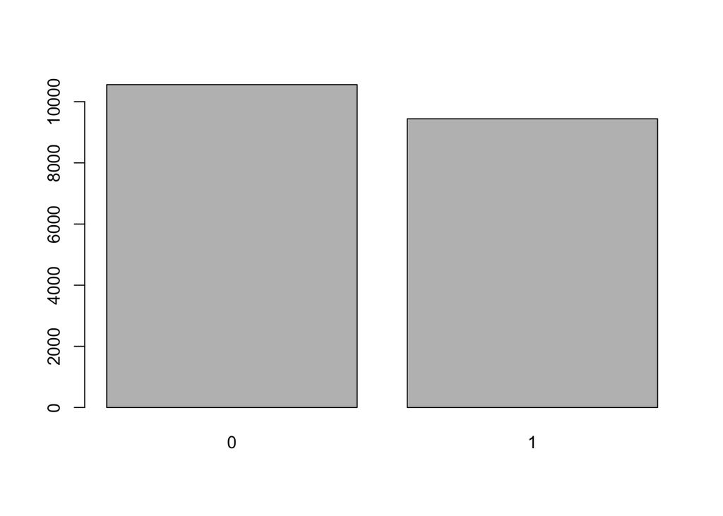

```r
smoke <- table(cdc$smoke100)

barplot(smoke)
```

# Exercise 2:

# Create a numerical summary for height and age, and compute the interquartile range for each. Compute the relative frequency distribution for gender and exerany. How many males are in the sample? What proportion of the sample reports being in excellent health?

## summary for height

```r
summary(cdc$height)
```

```
##    Min. 1st Qu.  Median    Mean 3rd Qu.    Max.
##   48.00   64.00   67.00   67.18   70.00   93.00
```

## summary for age

```r
summary(cdc$age)
```

```
##    Min. 1st Qu.  Median    Mean 3rd Qu.    Max.
##   18.00   31.00   43.00   45.07   57.00   99.00
```

## Interquartile range for Height

```r
IQR(cdc$height)
```

```
## [1] 6
```

## Interquartile range for age

```r
IQR(cdc$age)
```

```
## [1] 26
```

## Relative frequency distribution for gender

```r
table(cdc$gender) / 20000
```

```
##
##       m       f
## 0.47845 0.52155
```

## Relative frequency distribution for exerany

```r
table(cdc$exerany) /20000
```

```
##
##      0      1
## 0.2543 0.7457
```

## Number of Male in the sample

```r
table(cdc$gender, exclude = 'f')
```

```
##
##    m
## 9569
```

```r
male_exc <- subset(cdc, cdc$gender=="m" & cdc$genhlth=="excellent")
table(male_exc$gender, exclude = 'f')
```

```
##
##    m
## 2298
```

```r
table(cdc$gender,cdc$smoke100)
```

```
##
##        0    1
##   m 4547 5022
##   f 6012 4419
```

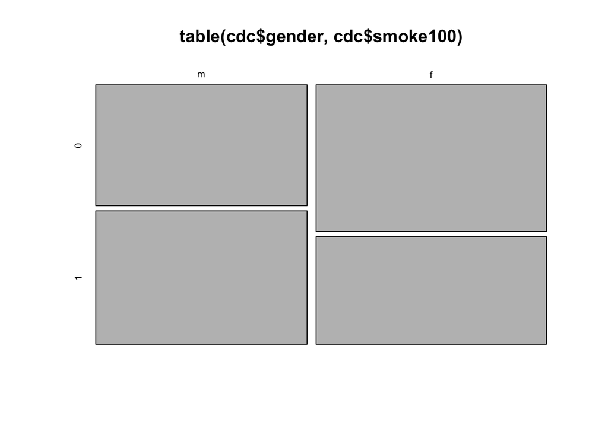

```r
mosaicplot(table(cdc$gender,cdc$smoke100))
```

## Exercise: 3

## What does the mosaic plot reveal about smoking habits and gender?

We can see that more males than females reported having smoked 100 cigarettes in their lifetime.

```r
dim(cdc)
```

```
## [1] 20000     9
```

```r
cdc[567,6]
```

```
## [1] 160
```

```r
names(cdc)
```

```
## [1] "genhlth"  "exerany"  "hlthplan" "smoke100" "height"   "weight"
## [7] "wtdesire" "age"      "gender"
```

```r
cdc[1:10,6]
```

```
##  [1] 175 125 105 132 150 114 194 170 150 180
```

```r
1:10
```

```
##  [1]  1  2  3  4  5  6  7  8  9 10
```

```r
cdc[1:10,]
```

```
##      genhlth exerany hlthplan smoke100 height weight wtdesire age gender
## 1       good       0        1        0     70    175      175  77      m
## 2       good       0        1        1     64    125      115  33      f
## 3       good       1        1        1     60    105      105  49      f
## 4       good       1        1        0     66    132      124  42      f
## 5  very good       0        1        0     61    150      130  55      f
## 6  very good       1        1        0     64    114      114  55      f
## 7  very good       1        1        0     71    194      185  31      m
## 8  very good       0        1        0     67    170      160  45      m
## 9       good       0        1        1     65    150      130  27      f
## 10      good       1        1        0     70    180      170  44      m
```

```r
cdc[,6]
```

[output not shown]

[output cut: 1162 more lines]

```r
cdc$weight
```

[output not shown]

[output cut: 1162 more lines]

```r
cdc$weight[567]
```

```
## [1] 160
```

```r
cdc$weight[1:10]
```

```
##  [1] 175 125 105 132 150 114 194 170 150 180
```

```r
cdc$gender == "m"
```

[output not shown]

[output cut: 1804 more lines]

```r
mdata <- subset(cdc, cdc$gender == "m")
```

```r
head(mdata)
```

```
##      genhlth exerany hlthplan smoke100 height weight wtdesire age gender
## 1       good       0        1        0     70    175      175  77      m
## 7  very good       1        1        0     71    194      185  31      m
## 8  very good       0        1        0     67    170      160  45      m
## 10      good       1        1        0     70    180      170  44      m
## 11 excellent       1        1        1     69    186      175  46      m
## 12      fair       1        1        1     69    168      148  62      m
```

```r
m_and_over30 <- subset(cdc, gender == "m" & age > 30)
```

# Exercise: 3.

## Create a new object called ‘under23_and_smoke’ that contains all observations of respondents under the age of 23 that have smoked 100 cigarettes in their lifetime. Write the command you used to create the new object as the answer to this exercise.

```r
under23_and_smoke <- subset(cdc, cdc$age<23 & cdc$smoke100==TRUE)
nrow(under23_and_smoke)
```

```
## [1] 620
```

## BoxPlot

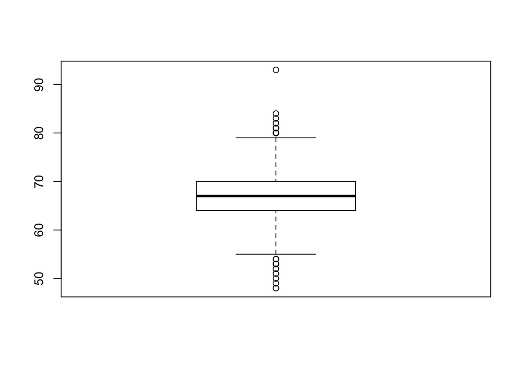

```r
boxplot(cdc$height)
```

```r
summary(cdc$height)
```

```
##    Min. 1st Qu.  Median    Mean 3rd Qu.    Max.
##   48.00   64.00   67.00   67.18   70.00   93.00
```

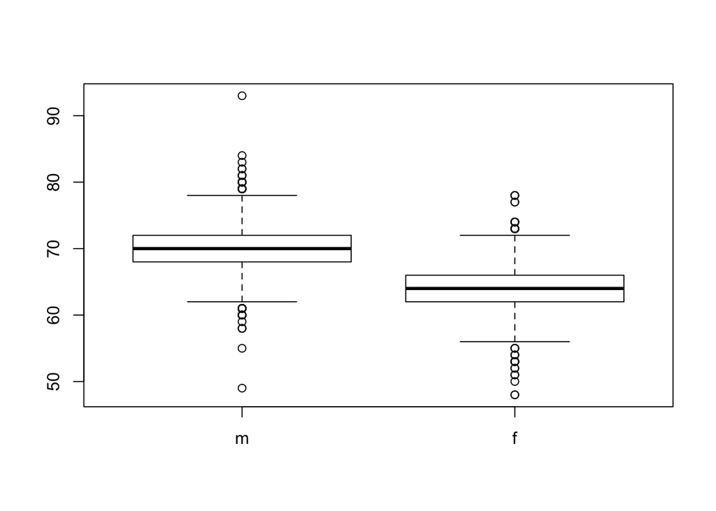

```r
boxplot(cdc$height ~ cdc$gender)
```

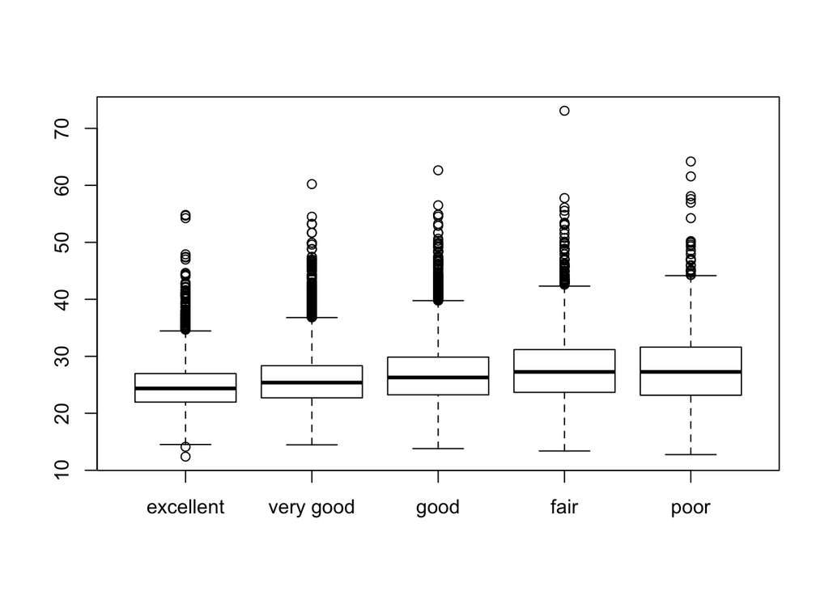

```r
bmi <- (cdc$weight / cdc$height^2) * 703
boxplot(bmi ~ cdc$genhlth)
```

## Exercise: 4

## What does this box plot show? Pick another categorical variable from the data set and see how it relates to BMI. List the variable you chose, why you might think it would have a relationship to BMI, and indicate what the figure seems to suggest.

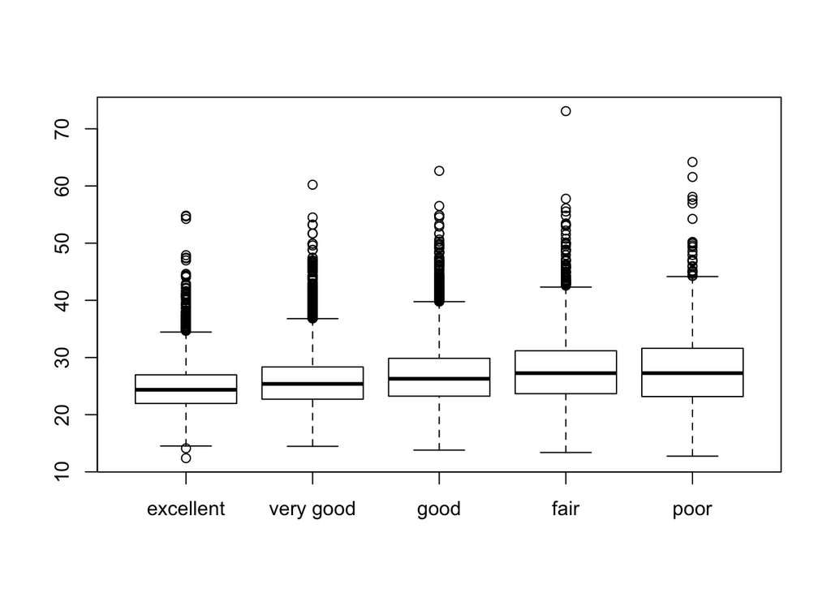

```r
bmi <- (cdc$weight / cdc$height^2) * 703
boxplot(bmi ~ cdc$genhlth)
```

We can see that bmi is inversely correlated with reported health condition.

bmi should be negatively correlated with exerany.

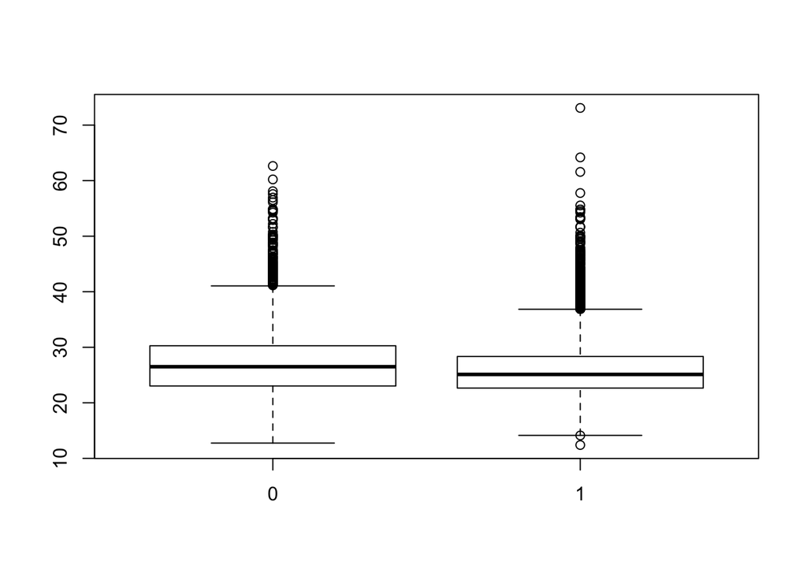

```r
boxplot(bmi ~ cdc$exerany)
```

## Histograms

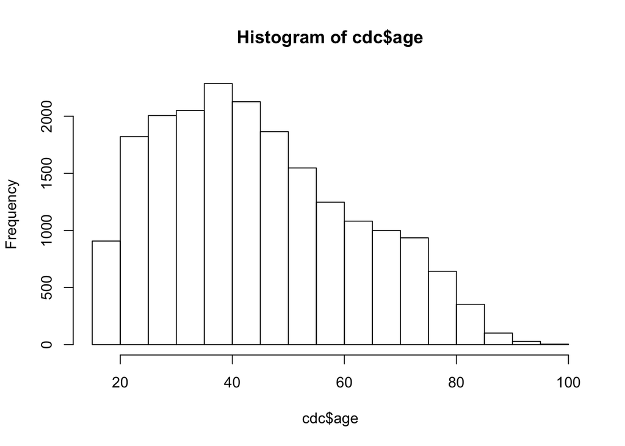

```r
hist(cdc$age)
```

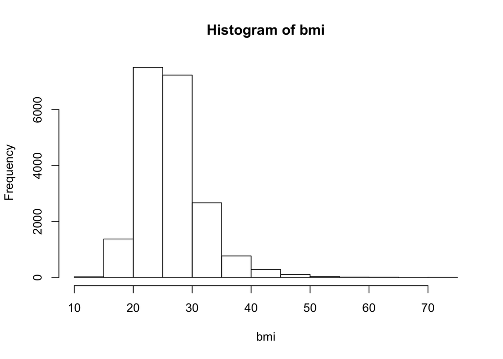

```r
hist(bmi)
```

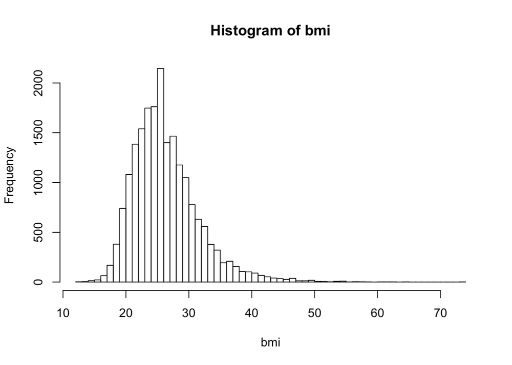

```r
hist(bmi, breaks = 50)
```

# On Your Own Section

## Make a scatterplot of weight versus desired weight. Describe the relationship between these two variables.

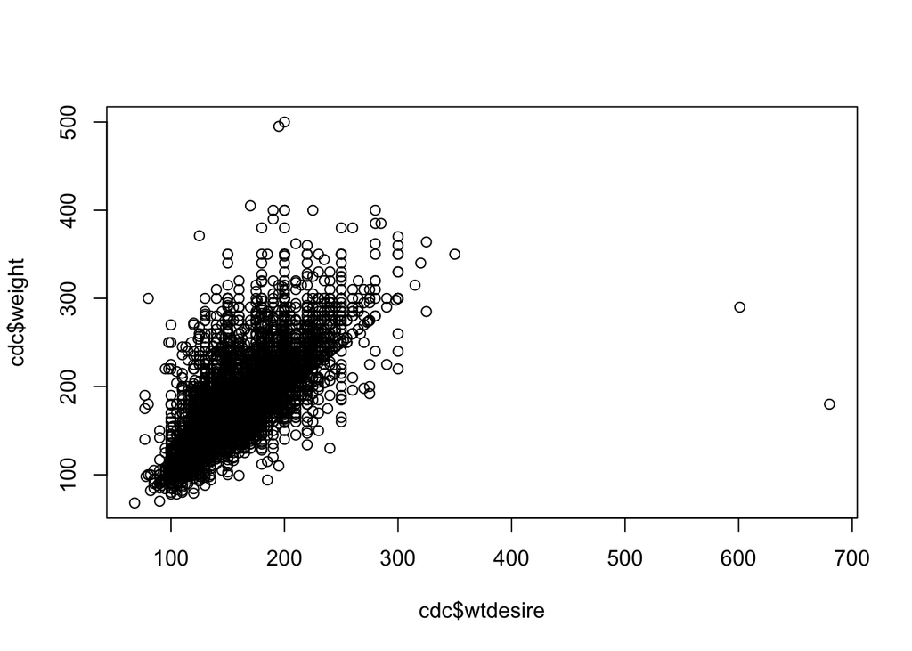

```r
plot(cdc$weight ~ cdc$wtdesire)
```

## Let’s consider a new variable: the difference between desired weight (‘wtdesire’) and current weight (‘weight). Create this new variable by subtracting the two columns in the data frame and assigning them to a new object called ’wdiff’

```r
wdiff <- cdc$wtdesire-cdc$weight
```

## What type of data is ‘wdiff’? If an observation ‘wdiff’ is 0, what does this mean about the person’s weight and desired weight. What if ‘wdiff’ is positive or negative?

wdiff is a Numerical (discrete) variable. If wdiff is 0, then the person is at their desired weight. If wdiff is negative, then the person wants to lose. If wdiff is positive then the person wants to gain weight

## Describe the distribution of ‘wdiff’ in terms of its center, shape, and spread, including any plots you use. What does this tell us about how people feel about their current weight?

```r
summary(wdiff)
```

```
##    Min. 1st Qu.  Median    Mean 3rd Qu.    Max.
## -300.00  -21.00  -10.00  -14.59    0.00  500.00
```

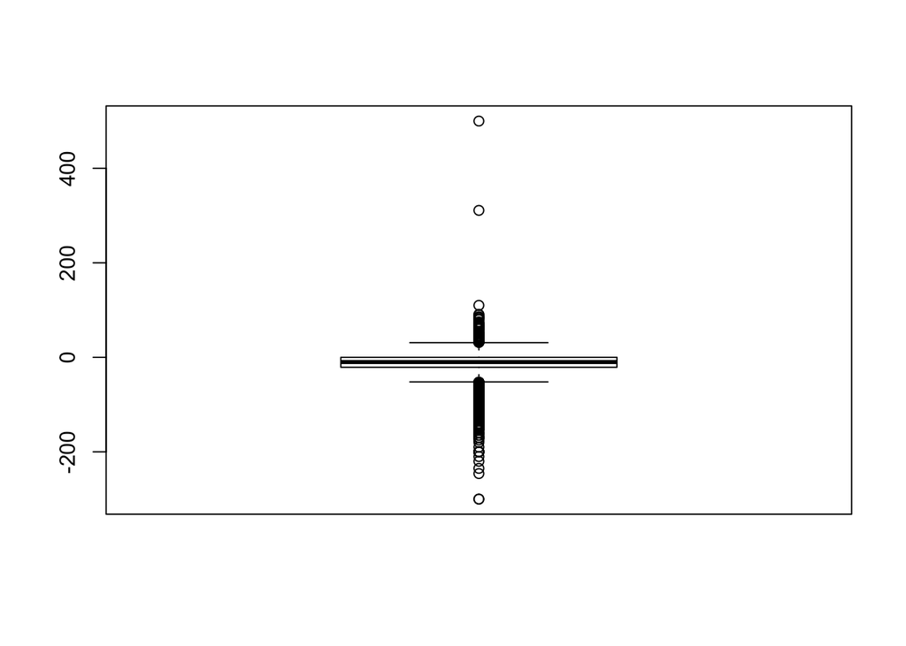

```r
boxplot(wdiff)
```

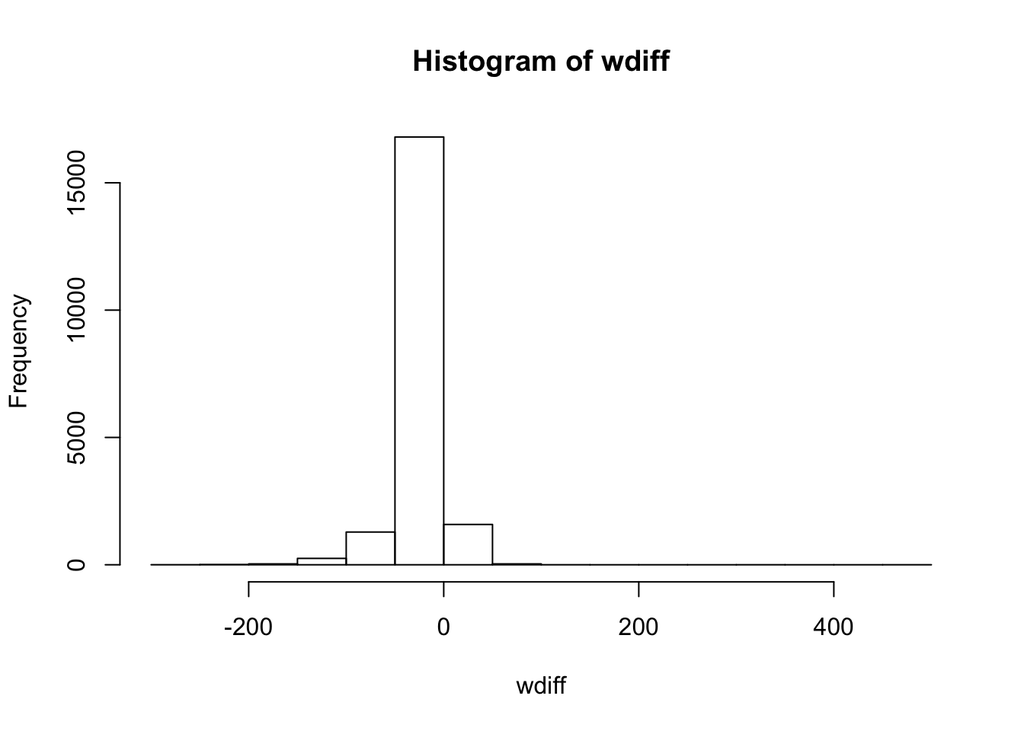

```r
hist(wdiff)
```

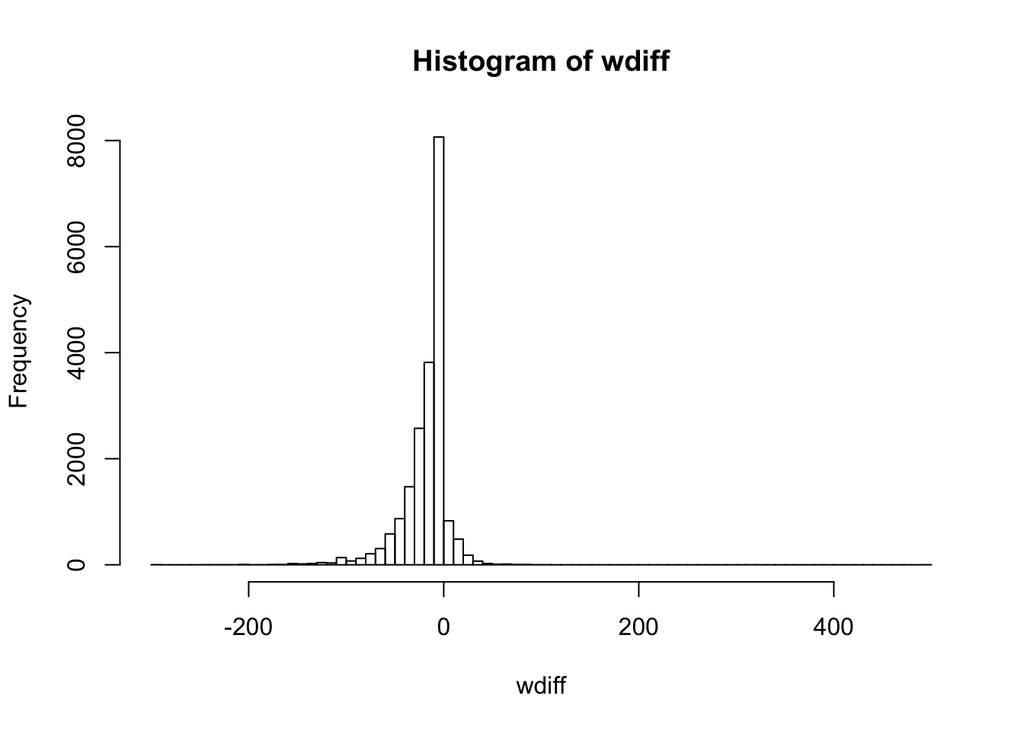

```r
hist(wdiff, breaks = 100)
```

Majority of the people are close to their ideal wieght. Since Mean is -14.59, the average amount of weight people want to lose is ~14.5

# Using numerical summaries and a side-by-side box plot, determine if men tend to view their weight differently than women.

```r
malewdiff <- subset(cdc, gender == "m", select = c(wtdesire, weight))
summary(malewdiff)
```

```
##     wtdesire         weight
##  Min.   : 77.0   Min.   : 78.0
##  1st Qu.:160.0   1st Qu.:165.0
##  Median :175.0   Median :185.0
##  Mean   :178.6   Mean   :189.3
##  3rd Qu.:190.0   3rd Qu.:210.0
##  Max.   :680.0   Max.   :500.0
```

```r
femalewdiff <- subset(cdc, gender == "f", select = c(wtdesire, weight))
summary(femalewdiff)
```

```
##     wtdesire         weight
##  Min.   : 68.0   Min.   : 68.0
##  1st Qu.:120.0   1st Qu.:128.0
##  Median :130.0   Median :145.0
##  Mean   :133.5   Mean   :151.7
##  3rd Qu.:145.0   3rd Qu.:170.0
##  Max.   :350.0   Max.   :495.0
```

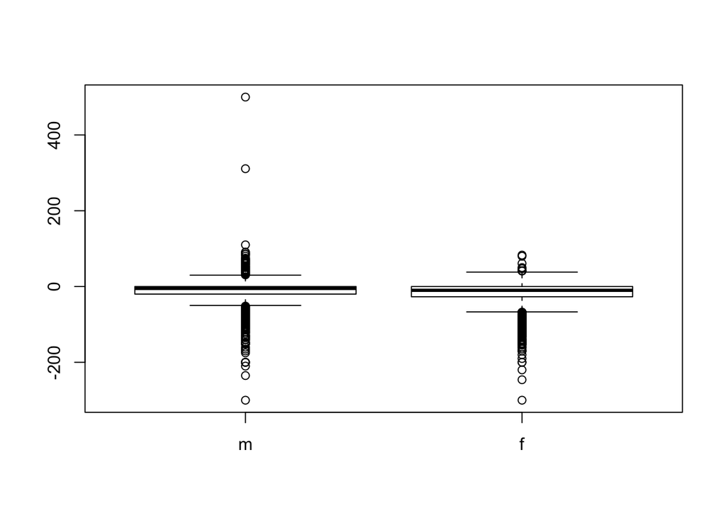

```r
boxplot(wdiff ~ cdc$gender)
```

From the tables and graphs, it’s can be concluded that men are closer to their ideal weight, while women prefer to lose more weight.

## Find the mean and standard deviation of weight` and determine what proportion of the weights are within one standard deviation of the mean.

## Mean

```r
meanweight <- mean(cdc$weight)
print(meanweight)
```

```
## [1] 169.683
```

## Standard Deviation

```r
sdweight <- sd(cdc$weight)
print(sdweight)
```

```
## [1] 40.08097
```

## In One Sd of Mean and proportion

```r
inOnestd = subset(cdc, (cdc$weight < (meanweight + sdweight)) & (cdc$weight > (meanweight - sdweight)))
proportion = dim(inOnestd)[1]/dim(cdc)[1]
print(proportion)
```

```
## [1] 0.7076
```